# DSCI353-353m-453: Class 14a Mapping Google Trends data For Thanksgiving

2008-351-351m-451-W14a-p2-GIS-Gtrends-Thnksgvng-Maps

Roger H. French, Raymond Weiser, Sameera Nalin Venkat

29 November, 2022

### Mapping Google Trends data For Thanksgiving

Lets use the R package `usmap`

- which enables incredibly easy and fast
  - creation of US maps in R.

In honor of US Thanksgiving,

- we’ll use the `gtrendsR` package
  - to pull US Google search results
    - on the keyword “thanksgiving”
  - and plot the popularity by state.

#### Install and Load Packages

```r
library(gtrendsR)
library(tidyverse)
library(cdlTools)
library(usmap)
#Set a color
orange <- "#C9592E"
```

#### Use Google Trends to get thanksgiving trends

- Use the [gTrendsR Package](https://cran.r-project.org/web/packages/gtrendsR/gtrendsR.pdf)
  - to get the query trends for thanksgiving in the US
  - for the past 24 hours

```r
thanksgiving <-
  gtrendsR::gtrends(keyword = "thanksgiving", geo = "US", time = "now 1-d") # last day

glimpse(thanksgiving)
```

```
List of 7
 $ interest_over_time :'data.frame':    180 obs. of  7 variables:
  ..$ date    : POSIXct[1:180], format: "2022-11-28 13:52:00" "2022-11-28 14:00:00" ...
  ..$ hits    : int [1:180] 99 100 100 95 92 93 92 89 89 87 ...
  ..$ keyword : chr [1:180] "thanksgiving" "thanksgiving" "thanksgiving" "thanksgiving" ...
  ..$ geo     : chr [1:180] "US" "US" "US" "US" ...
  ..$ time    : chr [1:180] "now 1-d" "now 1-d" "now 1-d" "now 1-d" ...
  ..$ gprop   : chr [1:180] "web" "web" "web" "web" ...
  ..$ category: int [1:180] 0 0 0 0 0 0 0 0 0 0 ...
 $ interest_by_country: NULL
 $ interest_by_region :'data.frame':    51 obs. of  5 variables:
  ..$ location: chr [1:51] "Utah" "Maryland" "New Jersey" "District of Columbia" ...
  ..$ hits    : int [1:51] 100 88 85 81 80 80 79 78 78 77 ...
  ..$ keyword : chr [1:51] "thanksgiving" "thanksgiving" "thanksgiving" "thanksgiving" ...
  ..$ geo     : chr [1:51] "US" "US" "US" "US" ...
  ..$ gprop   : chr [1:51] "web" "web" "web" "web" ...
 $ interest_by_dma    :'data.frame':    210 obs. of  5 variables:
  ..$ location: chr [1:210] "Glendive MT" "Alpena MI" "Salt Lake City UT" "Sherman TX-Ada OK" ...
  ..$ hits    : int [1:210] 100 87 83 82 67 66 64 63 62 62 ...
  ..$ keyword : chr [1:210] "thanksgiving" "thanksgiving" "thanksgiving" "thanksgiving" ...
  ..$ geo     : chr [1:210] "US" "US" "US" "US" ...
  ..$ gprop   : chr [1:210] "web" "web" "web" "web" ...
 $ interest_by_city   :'data.frame':    200 obs. of  5 variables:
  ..$ location: chr [1:200] "Pottsboro" "Highland" "Lehi" "Fayetteville" ...
  ..$ hits    : int [1:200] NA NA 100 NA NA NA NA NA NA NA ...
  ..$ keyword : chr [1:200] "thanksgiving" "thanksgiving" "thanksgiving" "thanksgiving" ...
  ..$ geo     : chr [1:200] "US" "US" "US" "US" ...
  ..$ gprop   : chr [1:200] "web" "web" "web" "web" ...
 $ related_topics     :'data.frame':    36 obs. of  6 variables:
  ..$ subject       : chr [1:36] "100" "9" "8" "6" ...
  ..$ related_topics: chr [1:36] "top" "top" "top" "top" ...
  ..$ value         : chr [1:36] "Thanksgiving" "Thanksgiving dinner" "Day" "Turkey meat" ...
  ..$ geo           : chr [1:36] "US" "US" "US" "US" ...
  ..$ keyword       : chr [1:36] "thanksgiving" "thanksgiving" "thanksgiving" "thanksgiving" ...
  ..$ category      : int [1:36] 0 0 0 0 0 0 0 0 0 0 ...
  ..- attr(*, "reshapeLong")=List of 4
  .. ..$ varying:List of 1
  .. .. ..- attr(*, "v.names")= chr "value"
  .. .. ..- attr(*, "times")= chr "top"
  .. ..$ v.names: chr "value"
  .. ..$ idvar  : chr "id"
  .. ..$ timevar: chr "related_topics"
 $ related_queries    :'data.frame':    50 obs. of  6 variables:
  ..$ subject       : chr [1:50] "100" "81" "57" "54" ...
  ..$ related_topics: chr [1:50] "top" "top" "top" "top" ...
  ..$ value         : chr [1:50] "thanksgiving 2022" "thanksgiving day" "after thanksgiving" "thanksgiving turkey" ...
  ..$ geo           : chr [1:50] "US" "US" "US" "US" ...
  ..$ keyword       : chr [1:50] "thanksgiving" "thanksgiving" "thanksgiving" "thanksgiving" ...
  ..$ category      : int [1:50] 0 0 0 0 0 0 0 0 0 0 ...
  ..- attr(*, "reshapeLong")=List of 4
  .. ..$ varying:List of 1
  .. .. ..- attr(*, "v.names")= chr "value"
  .. .. ..- attr(*, "times")= chr "top"
  .. ..$ v.names: chr "value"
  .. ..$ idvar  : chr "id"
  .. ..$ timevar: chr "related_topics"
 - attr(*, "class")= chr [1:2] "gtrends" "list"
```

```r
thanksgiving_2021 <-
  gtrends(keyword = "thanksgiving", geo = "US", time = "2021-11-23 2021-11-25", tz = 0 ) # last year

glimpse(thanksgiving_2021)
```

```
List of 7
 $ interest_over_time :'data.frame':    3 obs. of  7 variables:
  ..$ date    : POSIXct[1:3], format: "2021-11-23" "2021-11-24" ...
  ..$ hits    : int [1:3] 14 25 100
  ..$ keyword : chr [1:3] "thanksgiving" "thanksgiving" "thanksgiving"
  ..$ geo     : chr [1:3] "US" "US" "US"
  ..$ time    : chr [1:3] "2021-11-23 2021-11-25" "2021-11-23 2021-11-25" "2021-11-23 2021-11-25"
  ..$ gprop   : chr [1:3] "web" "web" "web"
  ..$ category: int [1:3] 0 0 0
 $ interest_by_country: NULL
 $ interest_by_region :'data.frame':    51 obs. of  5 variables:
  ..$ location: chr [1:51] "Florida" "North Carolina" "New Hampshire" "Massachusetts" ...
  ..$ hits    : int [1:51] 100 95 93 90 90 90 89 89 88 88 ...
  ..$ keyword : chr [1:51] "thanksgiving" "thanksgiving" "thanksgiving" "thanksgiving" ...
  ..$ geo     : chr [1:51] "US" "US" "US" "US" ...
  ..$ gprop   : chr [1:51] "web" "web" "web" "web" ...
 $ interest_by_dma    :'data.frame':    210 obs. of  5 variables:
  ..$ location: chr [1:210] "Orlando-Daytona Beach-Melbourne FL" "Miami-Ft. Lauderdale FL" "Panama City FL" "Wilmington NC" ...
  ..$ hits    : int [1:210] 100 97 94 92 90 90 90 89 89 88 ...
  ..$ keyword : chr [1:210] "thanksgiving" "thanksgiving" "thanksgiving" "thanksgiving" ...
  ..$ geo     : chr [1:210] "US" "US" "US" "US" ...
  ..$ gprop   : chr [1:210] "web" "web" "web" "web" ...
 $ interest_by_city   :'data.frame':    200 obs. of  5 variables:
  ..$ location: chr [1:200] "Sylvania" "Stockton" "Saint Simons Island" "Nicholasville" ...
  ..$ hits    : int [1:200] NA NA NA NA NA NA NA NA NA NA ...
  ..$ keyword : chr [1:200] "thanksgiving" "thanksgiving" "thanksgiving" "thanksgiving" ...
  ..$ geo     : chr [1:200] "US" "US" "US" "US" ...
  ..$ gprop   : chr [1:200] "web" "web" "web" "web" ...
 $ related_topics     :'data.frame':    20 obs. of  6 variables:
  ..$ subject       : chr [1:20] "100" "14" "7" "6" ...
  ..$ related_topics: chr [1:20] "top" "top" "top" "top" ...
  ..$ value         : chr [1:20] "Thanksgiving" "History" "Macy's Thanksgiving Day Parade" "Thanksgiving dinner" ...
  ..$ geo           : chr [1:20] "US" "US" "US" "US" ...
  ..$ keyword       : chr [1:20] "thanksgiving" "thanksgiving" "thanksgiving" "thanksgiving" ...
  ..$ category      : int [1:20] 0 0 0 0 0 0 0 0 0 0 ...
  ..- attr(*, "reshapeLong")=List of 4
  .. ..$ varying:List of 1
  .. .. ..- attr(*, "v.names")= chr "value"
  .. .. ..- attr(*, "times")= chr "top"
  .. ..$ v.names: chr "value"
  .. ..$ idvar  : chr "id"
  .. ..$ timevar: chr "related_topics"
 $ related_queries    :'data.frame':    50 obs. of  6 variables:
  ..$ subject       : chr [1:50] "100" "97" "87" "86" ...
  ..$ related_topics: chr [1:50] "top" "top" "top" "top" ...
  ..$ value         : chr [1:50] "history of thanksgiving" "thanksgiving history" "happy thanksgiving" "thanksgiving 2021" ...
  ..$ geo           : chr [1:50] "US" "US" "US" "US" ...
  ..$ keyword       : chr [1:50] "thanksgiving" "thanksgiving" "thanksgiving" "thanksgiving" ...
  ..$ category      : int [1:50] 0 0 0 0 0 0 0 0 0 0 ...
  ..- attr(*, "reshapeLong")=List of 4
  .. ..$ varying:List of 1
  .. .. ..- attr(*, "v.names")= chr "value"
  .. .. ..- attr(*, "times")= chr "top"
  .. ..$ v.names: chr "value"
  .. ..$ idvar  : chr "id"
  .. ..$ timevar: chr "related_topics"
 - attr(*, "class")= chr [1:2] "gtrends" "list"
```

```r
thanksgiving_2020 <-
  gtrends(keyword = "thanksgiving", geo = "US", time = "2020-11-26 2020-11-27") # 2nd year

glimpse(thanksgiving_2020)
```

```
List of 7
 $ interest_over_time :'data.frame':    2 obs. of  7 variables:
  ..$ date    : POSIXct[1:2], format: "2020-11-26" "2020-11-27"
  ..$ hits    : int [1:2] 100 21
  ..$ keyword : chr [1:2] "thanksgiving" "thanksgiving"
  ..$ geo     : chr [1:2] "US" "US"
  ..$ time    : chr [1:2] "2020-11-26 2020-11-27" "2020-11-26 2020-11-27"
  ..$ gprop   : chr [1:2] "web" "web"
  ..$ category: int [1:2] 0 0
 $ interest_by_country: NULL
 $ interest_by_region :'data.frame':    51 obs. of  5 variables:
  ..$ location: chr [1:51] "Florida" "Hawaii" "Maryland" "Texas" ...
  ..$ hits    : int [1:51] 100 98 92 90 89 89 88 87 86 86 ...
  ..$ keyword : chr [1:51] "thanksgiving" "thanksgiving" "thanksgiving" "thanksgiving" ...
  ..$ geo     : chr [1:51] "US" "US" "US" "US" ...
  ..$ gprop   : chr [1:51] "web" "web" "web" "web" ...
 $ interest_by_dma    :'data.frame':    210 obs. of  5 variables:
  ..$ location: chr [1:210] "Miami-Ft. Lauderdale FL" "North Platte NE" "Tampa-St. Petersburg (Sarasota) FL" "St. Joseph MO" ...
  ..$ hits    : int [1:210] 100 99 98 98 97 97 96 96 96 95 ...
  ..$ keyword : chr [1:210] "thanksgiving" "thanksgiving" "thanksgiving" "thanksgiving" ...
  ..$ geo     : chr [1:210] "US" "US" "US" "US" ...
  ..$ gprop   : chr [1:210] "web" "web" "web" "web" ...
 $ interest_by_city   :'data.frame':    200 obs. of  5 variables:
  ..$ location: chr [1:200] "Richmond West" "Pullman" "Saint Michael" "Maitland" ...
  ..$ hits    : int [1:200] NA NA NA NA NA NA NA NA NA NA ...
  ..$ keyword : chr [1:200] "thanksgiving" "thanksgiving" "thanksgiving" "thanksgiving" ...
  ..$ geo     : chr [1:200] "US" "US" "US" "US" ...
  ..$ gprop   : chr [1:200] "web" "web" "web" "web" ...
 $ related_topics     :'data.frame':    24 obs. of  6 variables:
  ..$ subject       : chr [1:24] "100" "20" "7" "7" ...
  ..$ related_topics: chr [1:24] "top" "top" "top" "top" ...
  ..$ value         : chr [1:24] "Thanksgiving" "History" "Happiness" "Macy's Thanksgiving Day Parade" ...
  ..$ geo           : chr [1:24] "US" "US" "US" "US" ...
  ..$ keyword       : chr [1:24] "thanksgiving" "thanksgiving" "thanksgiving" "thanksgiving" ...
  ..$ category      : int [1:24] 0 0 0 0 0 0 0 0 0 0 ...
  ..- attr(*, "reshapeLong")=List of 4
  .. ..$ varying:List of 1
  .. .. ..- attr(*, "v.names")= chr "value"
  .. .. ..- attr(*, "times")= chr "top"
  .. ..$ v.names: chr "value"
  .. ..$ idvar  : chr "id"
  .. ..$ timevar: chr "related_topics"
 $ related_queries    :'data.frame':    50 obs. of  6 variables:
  ..$ subject       : chr [1:50] "100" "99" "83" "71" ...
  ..$ related_topics: chr [1:50] "top" "top" "top" "top" ...
  ..$ value         : chr [1:50] "thanksgiving history" "history of thanksgiving" "open on thanksgiving" "thanksgiving 2020" ...
  ..$ geo           : chr [1:50] "US" "US" "US" "US" ...
  ..$ keyword       : chr [1:50] "thanksgiving" "thanksgiving" "thanksgiving" "thanksgiving" ...
  ..$ category      : int [1:50] 0 0 0 0 0 0 0 0 0 0 ...
  ..- attr(*, "reshapeLong")=List of 4
  .. ..$ varying:List of 1
  .. .. ..- attr(*, "v.names")= chr "value"
  .. .. ..- attr(*, "times")= chr "top"
  .. ..$ v.names: chr "value"
  .. ..$ idvar  : chr "id"
  .. ..$ timevar: chr "related_topics"
 - attr(*, "class")= chr [1:2] "gtrends" "list"
```

#### Gather Interest by State

- Select the data frame
  - for interest by state and
    - then convert the names of the states to FIPS codes
    - FIPS codes are
      - 2 characters for state,
      - 5 characters for county

The `usmap` package

- requires the data in FIPS format.

To gather the FIPS data,

- use the `usmap::fips()` function
  - to convert state name to code
  - [fips function reference](https://www.rdocumentation.org/packages/cdlTools/versions/0.14/topics/fips)

```r
thanksgivingStates <- thanksgiving$interest_by_region

thanksgivingStates$fips <- fips(thanksgivingStates$location)
glimpse(thanksgivingStates$fips)
```

```
 chr [1:51] "49" "24" "34" "11" "06" "42" "35" "48" "44" "33" "39" "51" "17" ...
```

```r
thanksgivingStates_2021 <- thanksgiving_2021$interest_by_region

thanksgivingStates_2021$fips <- fips(thanksgivingStates_2021$location)

thanksgivingStates_2020 <- thanksgiving_2020$interest_by_region

thanksgivingStates_2020$fips <- fips(thanksgivingStates_2020$location)
```

#### Plot interest with the US Map by state

- Create a US heatmap
  - with google search popularity
    - for the keyword “thanksgiving”

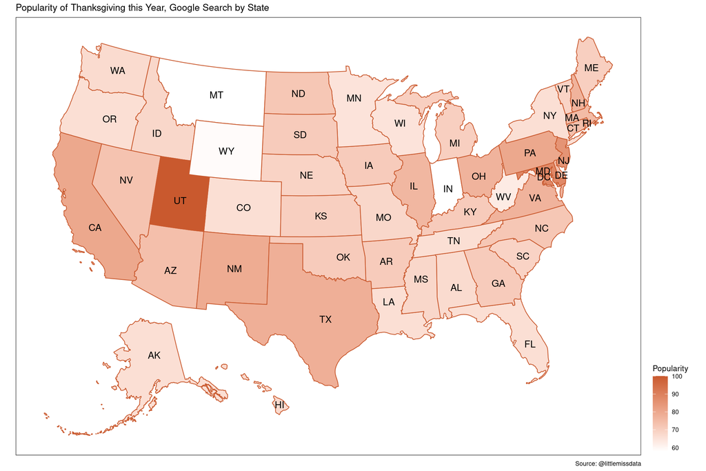

```r
plot_usmap(
  data = thanksgivingStates,
  values = "hits",
  color = orange,
  labels = TRUE
) +
  scale_fill_continuous(
    low = "white",
    high = orange,
    name = "Popularity",
    label = scales::comma
  ) +
  theme(legend.position = "right") +
  theme(panel.background = element_rect(colour = "black")) +
  labs(title = "Popularity of Thanksgiving this Year, Google Search by State", caption = "Source: @littlemissdata")
```

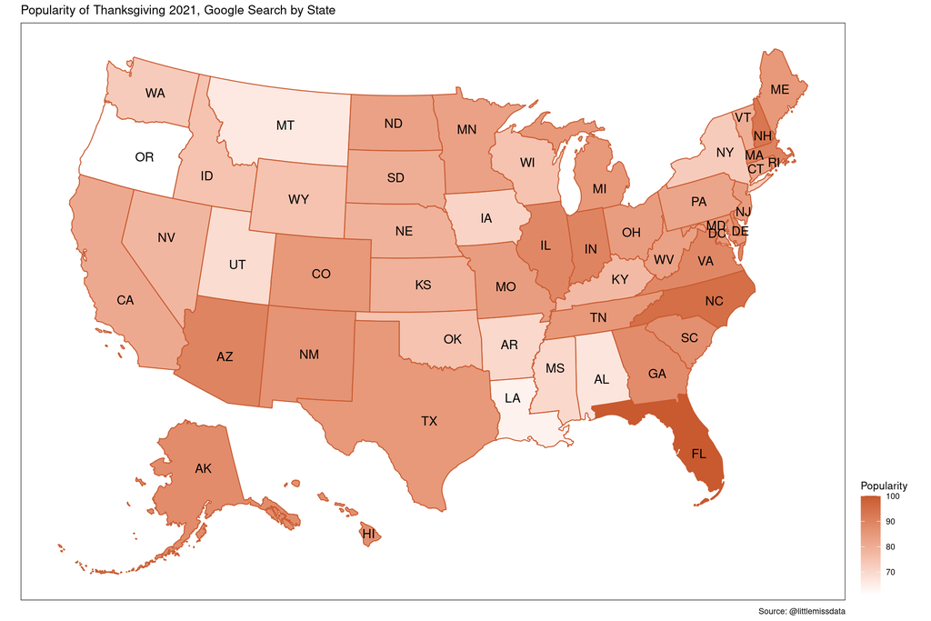

```r
plot_usmap(
  data = thanksgivingStates_2021,
  values = "hits",
  color = orange,
  labels = TRUE
) +
  scale_fill_continuous(
    low = "white",
    high = orange,
    name = "Popularity",
    label = scales::comma
  ) +
  theme(legend.position = "right") +
  theme(panel.background = element_rect(colour = "black")) +
  labs(title = "Popularity of Thanksgiving 2021, Google Search by State", caption = "Source: @littlemissdata")
```

And for two years ago, 2020?

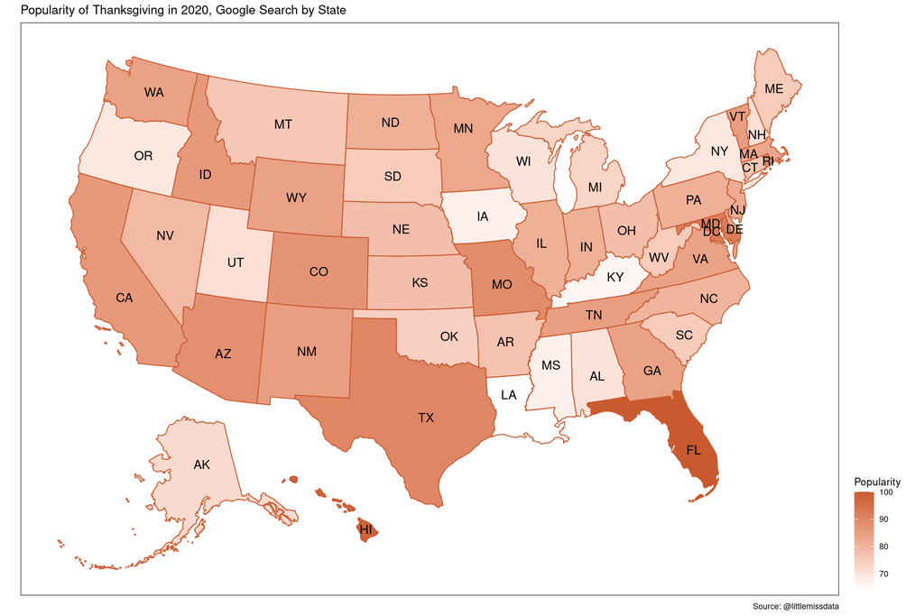

```r
plot_usmap(
  data = thanksgivingStates_2020,
  values = "hits",
  color = orange,
  labels = TRUE
) +
  scale_fill_continuous(
    low = "white",
    high = orange,
    name = "Popularity",
    label = scales::comma
  ) +
  theme(legend.position = "right") +
  theme(panel.background = element_rect(colour = "black")) +
  labs(title = "Popularity of Thanksgiving in 2020, Google Search by State", caption = "Source: @littlemissdata")
```

We can clearly see from the graphs above,

- differences between two years ago, last year and now.
  - about how excited people were for thanksgiving
- Lets look at the east coast
  - Now and Last Year at this time